# Analyzing Bike Trip Data

## Preliminary Wrangling

> This document explores a dataset containing attributes for bike rentals in July of 2020.

```python
# import all packages and set plots to be embedded inline
import numpy as np
import pandas as pd
import matplotlib.pyplot as plt
import seaborn as sb
from geopy.distance import geodesic

%matplotlib inline
```

```python
#load the dataset into a Pandas dataframe

df = pd.read_csv('202007-baywheels-tripdata.csv')
```

```python
#visual assessment of the dataset

df.head()
```

|  | ride_id | rideable_type | started_at | ended_at | start_station_name | start_station_id | end_station_name | end_station_id | start_lat | start_lng | end_lat | end_lng | member_casual |
| --- | --- | --- | --- | --- | --- | --- | --- | --- | --- | --- | --- | --- | --- |
| 0 | 68213B7BB2420043 | electric_bike | 2020-07-31 17:36:17 | 2020-07-31 17:48:13 | NaN | NaN | McAllister St at Baker St | 52.0 | 37.790000 | -122.460000 | 37.777414 | -122.441949 | casual |
| 1 | A64F0CD3A8E59529 | electric_bike | 2020-07-31 19:42:50 | 2020-07-31 19:49:54 | Buchanan St at North Point St | 400.0 | Buchanan St at North Point St | 400.0 | 37.804388 | -122.433510 | 37.804408 | -122.433509 | casual |
| 2 | B3690CA0F5179242 | electric_bike | 2020-07-31 17:18:46 | 2020-07-31 17:36:31 | NaN | NaN | Hyde St at Post St | 369.0 | 37.760000 | -122.410000 | 37.787422 | -122.416777 | casual |
| 3 | 162FFE2E157F4C8F | electric_bike | 2020-07-31 20:48:47 | 2020-07-31 21:05:04 | Jersey St at Castro St | 137.0 | NaN | NaN | 37.750576 | -122.433743 | 37.770000 | -122.420000 | casual |
| 4 | C5DA8100F428B934 | electric_bike | 2020-07-31 20:18:24 | 2020-07-31 20:24:26 | Market St at Steuart St | 16.0 | NaN | NaN | 37.794582 | -122.394791 | 37.790000 | -122.400000 | casual |

```python
#programmatic assessment of the dataset

df.info()
```

```
<class 'pandas.core.frame.DataFrame'>
RangeIndex: 154967 entries, 0 to 154966
Data columns (total 13 columns):
ride_id               154967 non-null object
rideable_type         154967 non-null object
started_at            154967 non-null object
ended_at              154967 non-null object
start_station_name    102589 non-null object
start_station_id      102589 non-null float64
end_station_name      100407 non-null object
end_station_id        100407 non-null float64
start_lat             154967 non-null float64
start_lng             154967 non-null float64
end_lat               154771 non-null float64
end_lng               154771 non-null float64
member_casual         154967 non-null object
dtypes: float64(6), object(7)
memory usage: 15.4+ MB
```

```python
#check for null values

df.isnull().sum()
```

```
ride_id                   0
rideable_type             0
started_at                0
ended_at                  0
start_station_name    52378
start_station_id      52378
end_station_name      54560
end_station_id        54560
start_lat                 0
start_lng                 0
end_lat                 196
end_lng                 196
member_casual             0
dtype: int64
```

```python
#remove rows with null values:

df_clean = df.copy()
df_clean = df_clean.dropna()
df_clean.isnull().sum()
```

```
ride_id               0
rideable_type         0
started_at            0
ended_at              0
start_station_name    0
start_station_id      0
end_station_name      0
end_station_id        0
start_lat             0
start_lng             0
end_lat               0
end_lng               0
member_casual         0
dtype: int64
```

```python
#check for duplicates

df_clean.duplicated().sum()
```

```
0
```

```python
# change two columns to datetime data type:

df_clean['started_at'] = pd.to_datetime(df_clean['started_at'])
df_clean['ended_at'] = pd.to_datetime(df_clean['ended_at'])
```

```python
#pull day out of timestamps

df_clean['start_day'] = df_clean.started_at.dt.strftime('%A')
df_clean['end_day'] = df_clean.ended_at.dt.strftime('%A')
```

```python
#pull hour out of timestamps

df_clean['start_hour'] = df_clean.started_at.dt.strftime('%H')
df_clean['end_hour'] = df_clean.ended_at.dt.strftime('%H')
```

```python
#pull month out of timestamps

df_clean['start_month'] = df_clean.started_at.dt.strftime('%B')
df_clean['end_month'] = df_clean.ended_at.dt.strftime('%B')
```

```python
#extract duration of trip in seconds
#https://stackoverflow.com/questions/51491724/calculate-difference-of-2-dates-in-minutes-in-pandas
df_clean['duration_sec'] = (df_clean['ended_at'] - df_clean['started_at']).dt.total_seconds()
df_clean['duration_sec'].head()
```

```
1     424.0
12    708.0
13     29.0
17    744.0
18    839.0
Name: duration_sec, dtype: float64
```

```python
# change start_day, end_day, start_month, end_month, start_hour, end_hour into ordered categorical types

ordinal_var_dict = {'start_day': ['Sunday','Monday','Tuesday','Wednesday','Thursday', 'Friday', 'Saturday'],
                    'end_day': ['Sunday','Monday','Tuesday','Wednesday','Thursday', 'Friday', 'Saturday'],
                    'start_month': ['January', 'February', 'March', 'April', 'May', 'June', 'July', 'August', 'September', 'October', 'November', 'December'],
                    'end_month': ['January', 'February', 'March', 'April', 'May', 'June', 'July', 'August', 'September', 'October', 'November', 'December'],
                    'start_hour': ['00', '01', '02', '03', '04', '05', '06', '07', '08', '09', '10', '11', '12', '13', '14', '15', '16', '17', '18', '19', '20', '21', '22', '23'],
                    'end_hour': ['00', '01', '02', '03', '04', '05', '06', '07', '08', '09', '10', '11', '12', '13', '14', '15', '16', '17', '18', '19', '20', '21', '22', '23']
                   }

for var in ordinal_var_dict:
    ordered_var = pd.api.types.CategoricalDtype(ordered = True,
                                                categories = ordinal_var_dict[var])
    df_clean[var] = df_clean[var].astype(ordered_var)
```

```python
#change start_station_id and end_station_id to string

df_clean['start_station_id'] = df_clean['start_station_id'].astype(str)
df_clean['end_station_id'] = df_clean['end_station_id'].astype(str)
```

```python
#drop unnecessary columns

df_clean = df_clean.drop(['start_station_name', 'end_station_name'], axis = 1)
```

```python
#https://stackoverflow.com/questions/44446862/calculate-distance-between-latitude-and-longitude-in-dataframe
#https://stackoverflow.com/questions/62858552/why-cant-i-import-geopy-distance-vincenty-on-jupyter-notebook-i-installed-ge

# 1. define a function that calculates the distance in meters from latitude and longitude coordinatesfrom geopy.distance import geodesic

def distance_cal(row):
    start = (row['start_lat'], row['start_lng'])
    end = (row['end_lat'], row['end_lng'])

    return geodesic(start, end).meters

# 2. then create a new column and use a lambda expression to apply the function to the different latitude and longitude columns
df_clean['distance'] = df_clean.apply(lambda row: distance_cal(row), axis = 1)
```

```python
#check dataset for changes

df_clean.info()
```

```
<class 'pandas.core.frame.DataFrame'>
Int64Index: 83530 entries, 1 to 154966
Data columns (total 19 columns):
ride_id             83530 non-null object
rideable_type       83530 non-null object
started_at          83530 non-null datetime64[ns]
ended_at            83530 non-null datetime64[ns]
start_station_id    83530 non-null object
end_station_id      83530 non-null object
start_lat           83530 non-null float64
start_lng           83530 non-null float64
end_lat             83530 non-null float64
end_lng             83530 non-null float64
member_casual       83530 non-null object
start_day           83530 non-null category
end_day             83530 non-null category
start_hour          83530 non-null category
end_hour            83530 non-null category
start_month         83530 non-null category
end_month           83530 non-null category
duration_sec        83530 non-null float64
distance            83530 non-null float64
dtypes: category(6), datetime64[ns](2), float64(6), object(5)
memory usage: 9.4+ MB
```

```python
#get a summary of the numeric data
#focus only on the last 2 columns

df_clean.describe()
```

|  | start_lat | start_lng | end_lat | end_lng | duration_sec | distance |
| --- | --- | --- | --- | --- | --- | --- |
| count | 83530.000000 | 83530.000000 | 83530.000000 | 83530.000000 | 8.353000e+04 | 8.353000e+04 |
| mean | 37.766564 | -122.377667 | 37.766643 | -122.369971 | 1.785725e+03 | 2.566170e+03 |
| std | 0.091260 | 0.113420 | 0.091240 | 0.791369 | 2.475609e+04 | 6.669596e+04 |
| min | 37.308990 | -122.509114 | 37.308999 | -122.509190 | -3.762000e+03 | 0.000000e+00 |
| 25% | 37.766862 | -122.426825 | 37.766883 | -122.426603 | 4.590000e+02 | 7.939148e+02 |
| 50% | 37.777052 | -122.409412 | 37.776951 | -122.408627 | 7.960000e+02 | 1.646980e+03 |
| 75% | 37.791300 | -122.391230 | 37.792878 | -122.391242 | 1.385000e+03 | 2.779067e+03 |
| max | 37.880222 | -121.863656 | 37.880222 | -42.344893 | 2.247601e+06 | 6.816769e+06 |

One more thing that can be done to clean up the dataset is to remove the outliers. I will use the following formulas to remove the outliers:

High: Q3 + 1.5 *IQR Low: Q1 - 1.5* IQR

Where Q3 is the third quartile, Q1 is the first quartile, and IQR is the interquartile range (Q3 - Q1).

```python
#calculate duration_sec outliers

high_sec = 1385 + (1.5 * (1385 - 459))
low_sec = 459 - (1.5 * (1385 - 459))
print(high_sec, low_sec)
```

```
2774.0 -930.0
```

```python
#calculate distance outliers

high_dis = 2779.067 + (1.5 * (2779.067 - 793.9148))
low_dis = 793.9148 - (1.5 * (2779.067 - 793.9148))
print(high_dis, low_dis)
```

```
5756.7953 -2183.8134999999997
```

```python
#filter the dataset to exclude duration_sec and distance outliers

df_clean = df_clean.query('duration_sec < 2774 & duration_sec > -930 & distance < 5756.7953 & distance > -2183.813499999997')
```

```python
df_clean.info()
```

```
<class 'pandas.core.frame.DataFrame'>
Int64Index: 75921 entries, 1 to 154966
Data columns (total 19 columns):
ride_id             75921 non-null object
rideable_type       75921 non-null object
started_at          75921 non-null datetime64[ns]
ended_at            75921 non-null datetime64[ns]
start_station_id    75921 non-null object
end_station_id      75921 non-null object
start_lat           75921 non-null float64
start_lng           75921 non-null float64
end_lat             75921 non-null float64
end_lng             75921 non-null float64
member_casual       75921 non-null object
start_day           75921 non-null category
end_day             75921 non-null category
start_hour          75921 non-null category
end_hour            75921 non-null category
start_month         75921 non-null category
end_month           75921 non-null category
duration_sec        75921 non-null float64
distance            75921 non-null float64
dtypes: category(6), datetime64[ns](2), float64(6), object(5)
memory usage: 8.5+ MB
```

### What is the structure of your dataset?

(first) --> (last)

start/end_hour: 0, 1, 2, 3, 4, 5, 6, 7, 8, 9, 10, 11, 12, 13, 14, 15, 16, 17, 18, 19, 20, 21, 22, 23  
start/end_day: Sunday, Monday, Tuesday, Wednesday, Thursday, Friday, Saturday  
start/end_month: January, February, March, April, May, June, July, August, September, October, November, December

### What is/are the main feature(s) of interest in your dataset?

I am interested in finding patterns in the ride time and distance between members and casual users. I am also interested to see if there are certain days of the week that members and casual users go on more trips. I also want to see if there are days of the week that members and casual users spend more time or go for longer rides on the bikes.

### What features in the dataset do you think will help support your investigation into your feature(s) of interest?

The member_casual, rideable_type, start_day, start_hour and start_month featues are the features I am most interested in.

## Univariate Exploration

> Let's start by looking at the two numeric variables: duration_sec and distance.

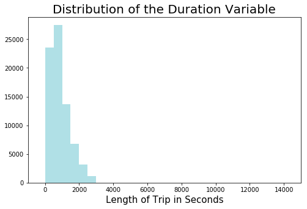

```python
#start with a standard-scaled plot
#change the color: https://matplotlib.org/2.0.2/examples/color/named_colors.html
#change the color palette: https://matplotlib.org/2.0.2/examples/color/colormaps_reference.html
binsize = 500
bins = np.arange(0, df_clean['duration_sec'].max()+binsize, binsize)

plt.figure(figsize=[8, 5])
plt.hist(data = df_clean, x = 'duration_sec', bins = bins, color = 'powderblue')
plt.xlabel('Length of Trip in Seconds', fontsize = 15)
plt.title('Distribution of the Duration Variable', fontsize = 20)
plt.xlim([-1000,15000])
plt.show()
```

We can see that there are some outliers in the duration data, so we will take a look at the log distribution of this data below.

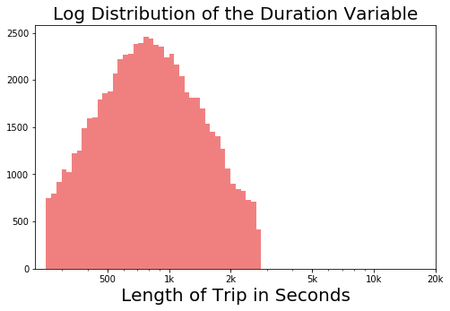

```python
# there's a long tail in the distribution, so let's put it on a log scale instead
log_binsize = 0.025
bins = 10 ** np.arange(2.4, np.log10(df_clean['duration_sec'].max())+log_binsize, log_binsize)

plt.figure(figsize=[8, 5])
plt.hist(data = df_clean, x = 'duration_sec', bins = bins, color = 'lightcoral')
plt.xscale('log')
plt.xticks([500, 1e3, 2e3, 5e3, 1e4, 2e4], [500, '1k', '2k', '5k', '10k', '20k'])
plt.xlabel('Length of Trip in Seconds', fontsize = 20)
plt.title('Log Distribution of the Duration Variable', fontsize = 20)
plt.show()
```

The log distribution of duration appears to be normally distributed with most values around 750 seconds. Next we will take a look at the distribution of the distance column.

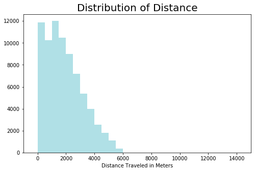

```python
# start with a standard-scaled plot
binsize = 500
bins = np.arange(0, df_clean['distance'].max()+binsize, binsize)

plt.figure(figsize=[8, 5])
plt.hist(data = df_clean, x = 'distance', bins = bins, color = 'powderblue')
plt.xlabel('Distance Traveled in Meters')
plt.title('Distribution of Distance', fontsize = 20)
plt.xlim([-1000,15000])
plt.show()
```

The distance traveled in meters also appears to be right skewed. This tail would have been longer if we did not remove the outliers earlier, so we will take a look at the log distribution of this column next.

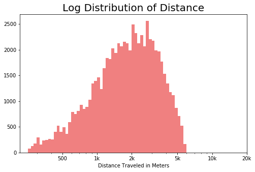

```python
# there's a long tail in the distribution, so let's put it on a log scale instead
log_binsize = 0.025
bins = 10 ** np.arange(2.4, np.log10(df_clean['distance'].max())+log_binsize, log_binsize)

plt.figure(figsize=[8, 5])
plt.hist(data = df_clean, x = 'distance', bins = bins, color = 'lightcoral')
plt.xscale('log')
plt.xticks([500, 1e3, 2e3, 5e3, 1e4, 2e4], [500, '1k', '2k', '5k', '10k', '20k'])
plt.xlabel('Distance Traveled in Meters')
plt.title('Log Distribution of Distance', fontsize = 20)
plt.show()
```

The log distribution appears to be more normally distributed, but I it appears to have a slight skew to the left. The peak of this distribution appears to occur between 2,000 and 3,000 meters. Next we will take a look at the categorical variables.

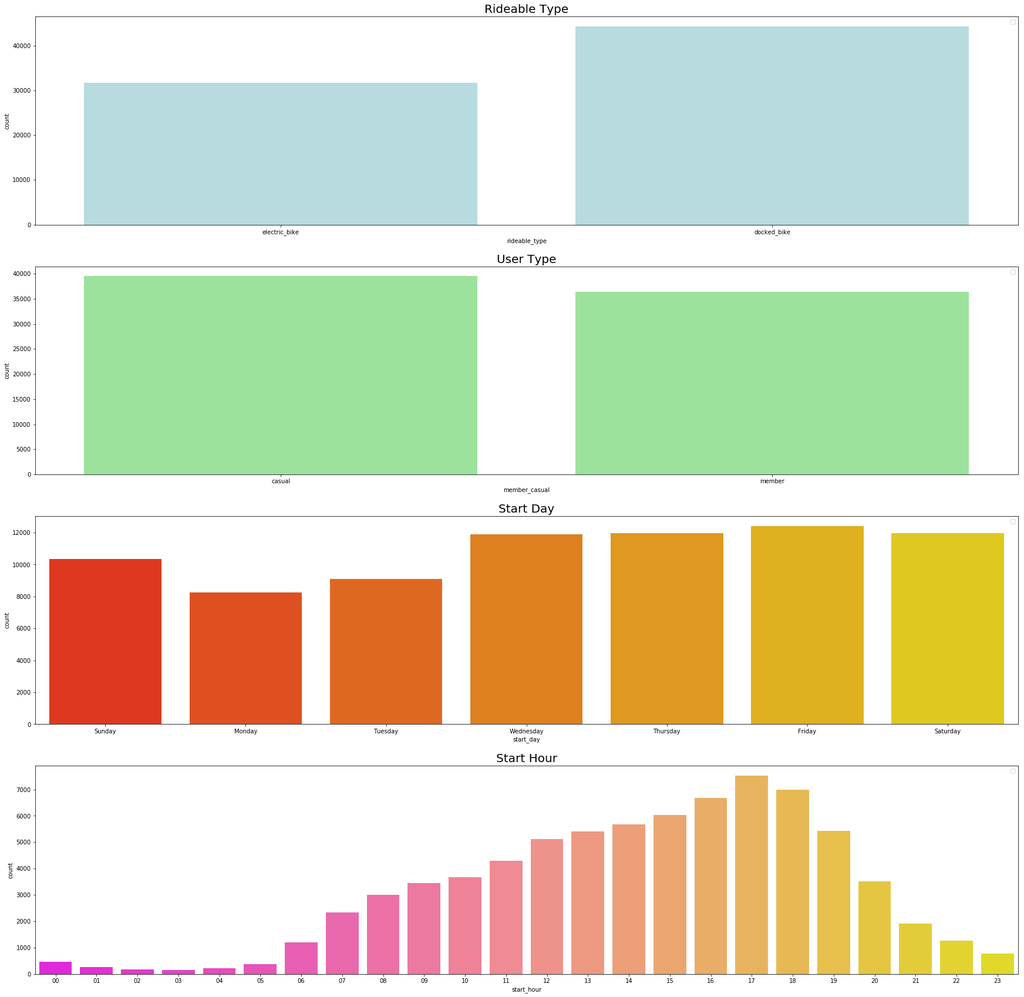

```python
#get rid of no legend error: https://stackoverflow.com/questions/59024250/suppress-warningmatplotlib-legendno-handles-with-labels-found-to-put-in-legend

import logging
logging.getLogger().setLevel(logging.CRITICAL)

# since there's only three subplots to create, using the full data should be fine.
plt.figure(figsize = [30, 30]);

# subplot 1: rideable type
ax = plt.subplot(4, 1, 1);
sb.countplot(data = df_clean, x = 'rideable_type', color = 'powderblue');
ax.legend(loc = 0, ncol = 2);
ax.set_title('Rideable Type', fontsize = 20);

# subplot 2: user type
ax = plt.subplot(4, 1, 2);
sb.countplot(data = df_clean, x = 'member_casual', color = 'lightgreen');
ax.legend(ncol = 2); # re-arrange legend to reduce overlapping
ax.set_title('User Type', fontsize = 20);

# subplot 3: start day
ax = plt.subplot(4, 1, 3);
sb.countplot(data = df_clean, x = 'start_day', palette = 'autumn')
ax.legend(loc = 0, ncol = 2); # re-arrange legend to remove overlapping
ax.set_title('Start Day', fontsize = 20);

# subplot 4: start hour
ax = plt.subplot(4, 1, 4);
sb.countplot(data = df_clean, x = 'start_hour', palette = 'spring');
ax.legend(loc = 0, ncol = 3); # re-arrange legend to remove overlapping
ax.set_title('Start Hour', fontsize = 20);

plt.show();
```

Here we can see that there are far more docked bikes in use than electric bikes, there are more casual users than members, Friday is the day that most of the rentals occur, and most people start their rides in the early evening around 5 PM.

### Discuss the distribution(s) of your variable(s) of interest. Were there any unusual points? Did you need to perform any transformations?

> Both the distance and duration_sec variables had tails to the right that were reduced significantly by the removal of outliers. They would have been even more skewed to the right, so I decided to look at each using a log transform. The duration_sec variable has a normal distribution when looked at using the transform with a peak at around 800 seconds. The distance variable appears to have a slightly left skewed distribution using the transformation, and it has a peak of between 2,000 to 3,000 meters.

### Of the features you investigated, were there any unusual distributions? Did you perform any operations on the data to tidy, adjust, or change the form of the data? If so, why did you do this?

> Outliers were removed in the cleaning phase due to some large values in each of the numeric variables that occurred. These were removed because they do not accurately charactize what an average trip looks like, and I did not want to skew the analysis with these points.

## Bivariate Exploration

> First, I want to look at the interactions between a few of the different categorical variables using bar graphs.

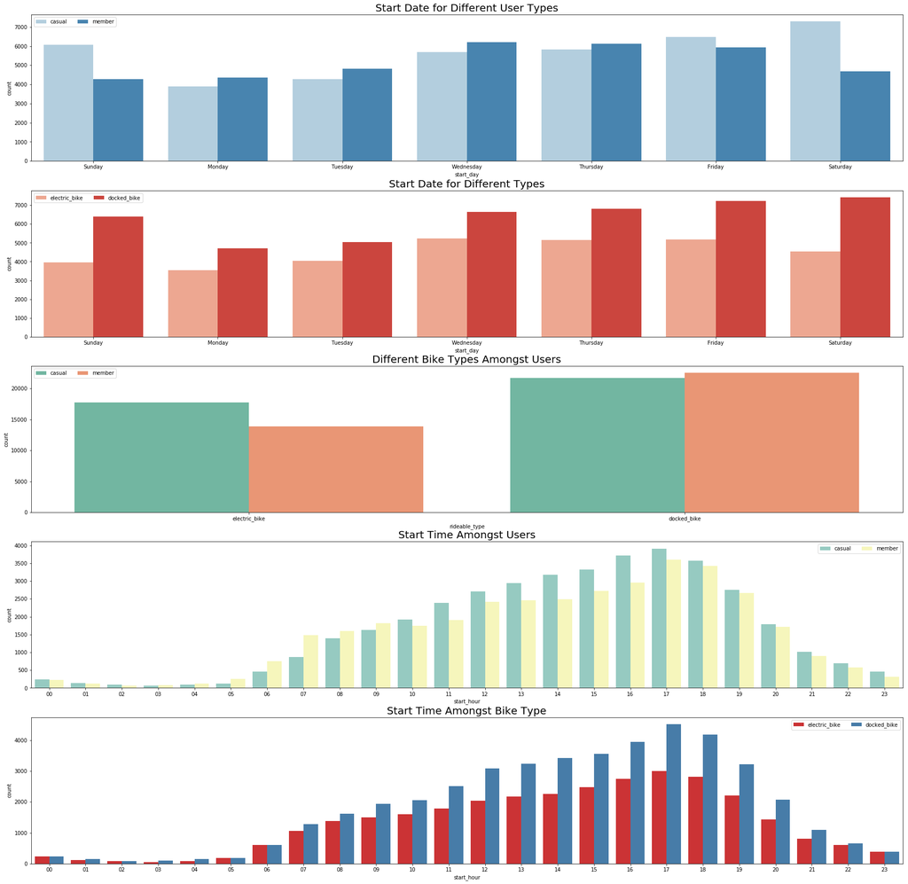

```python
# since there's only three subplots to create, using the full data should be fine.
plt.figure(figsize = [30, 30])

# subplot 1: day of start for different users
ax = plt.subplot(5, 1, 1)
sb.countplot(data = df_clean, x = 'start_day', hue = 'member_casual', palette = 'Blues')
ax.legend(loc = 0, ncol = 2)
ax.set_title('Start Date for Different User Types', fontsize = 20)

# subplot 2: day of start for different bike types
ax = plt.subplot(5, 1, 2)
sb.countplot(data = df_clean, x = 'start_day', hue = 'rideable_type', palette = 'Reds')
ax.legend(ncol = 2) # re-arrange legend to reduce overlapping
ax.set_title('Start Date for Different Types', fontsize = 20)

# subplot 3: different bikes used by different user types
ax = plt.subplot(5, 1, 3)
sb.countplot(data = df_clean, x = 'rideable_type', hue = 'member_casual', palette = 'Set2')
ax.legend(loc = 0, ncol = 2) # re-arrange legend to remove overlapping
ax.set_title('Different Bike Types Amongst Users', fontsize = 20)

# subplot 4: start time for different user type, use different color palette
ax = plt.subplot(5, 1, 4)
sb.countplot(data = df_clean, x = 'start_hour', hue = 'member_casual', palette = 'Set3')
ax.legend(loc = 0, ncol = 3) # re-arrange legend to remove overlapping
ax.set_title('Start Time Amongst Users', fontsize = 20)

# subplot 5: bike type used at different start times
ax = plt.subplot(5, 1, 5)
sb.countplot(data = df_clean, x = 'start_hour', hue = 'rideable_type', palette = 'Set1')
ax.legend(loc = 0, ncol = 3) # re-arrange legend to remove overlapping
ax.set_title('Start Time Amongst Bike Type', fontsize = 20)

plt.show()
```

In the first graph we can see that casual riders typically used the bikes on Fridays, Saturdays, and Sundays, and we see that members typically used the bikes on Wednesday, Thursdays, and Fridays. Between the different types of users, there appears to be a similar preference for docked bikes as opposed to electric bikes, and there does not appear to be a relationship between the type of bike and a specific day of the week. We also see that for both the user type and the bike type, usage spikes in the early evening hours. Next I want to look at the relationship between the two different numeric variables.

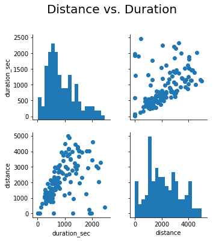

```python
# how to position title: https://stackoverflow.com/questions/55767312/how-to-position-suptitle

numeric_vars = ['duration_sec', 'distance']
samples = np.random.choice(df_clean.shape[0], 500, replace = False)
df_samp = df_clean.loc[samples,:]

g = sb.PairGrid(data = df_samp, vars = numeric_vars);
g = g.map_diag(plt.hist, bins = 20);
g.map_offdiag(plt.scatter);
g.fig.suptitle('Distance vs. Duration', fontsize = 20, y = 1.1);
```

Here we can see a positive correlation between the two numeric variables by observing the scatterplot. We can also see that this relationship is not very strong as the points are all over the graph. Next, I will look at the correlation coefficient value between the two numeric values to verify that this is the case.

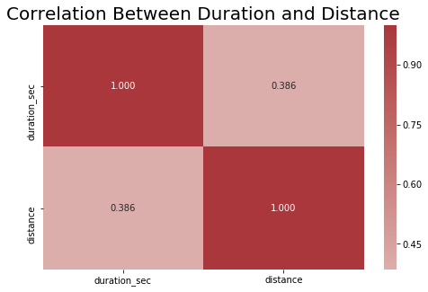

```python
plt.figure(figsize = [8, 5])
sb.heatmap(df_clean[numeric_vars].corr(), annot = True, fmt = '.3f',
           cmap = 'vlag', center = 0)
plt.title('Correlation Between Duration and Distance', fontsize = 20)
plt.show()
```

Here we can see a value of .386 for the correlation coefficient. This confirms our observation in the previous visualization that there is a weak positive correlation between the two numeric variables.

### Talk about some of the relationships you observed in this part of the investigation. How did the feature(s) of interest vary with other features in the dataset?

> It appears that most users, whether casual or a member, prefer to use the bikes in the early evening hours, and their use appears to come on different days of the week between the different member types. We can also see that the length of time spent on these bikes is not a direct indication of how far the users go on the bikes.

### Did you observe any interesting relationships between the other features (not the main feature(s) of interest)?

> One interesting relationship is the preference of docked bikes versus electric bikes between the different user types.

## Multivariate Exploration

> Create plots of three or more variables to investigate your data even further. Make sure that your investigations are justified, and follow from your work in the previous sections.

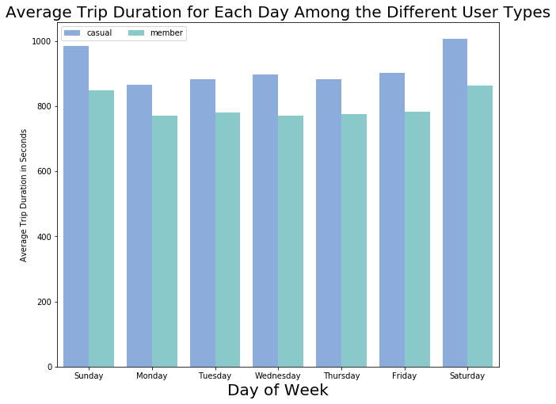

```python
plt.figure(figsize = [10,8])
sb.barplot(data=df_clean, x='start_day', y='duration_sec', hue = 'member_casual', palette = 'winter', capsize = .1, alpha = .5, ci = None);
plt.xlabel('Day of Week', fontsize = 20);
plt.ylabel('Average Trip Duration in Seconds')
plt.title('Average Trip Duration for Each Day Among the Different User Types', fontsize = 20)
plt.legend(ncol = 2);
```

With this visualization, we can see that both casual users and members spent more time riding the bikes on Saturdays and Sundays

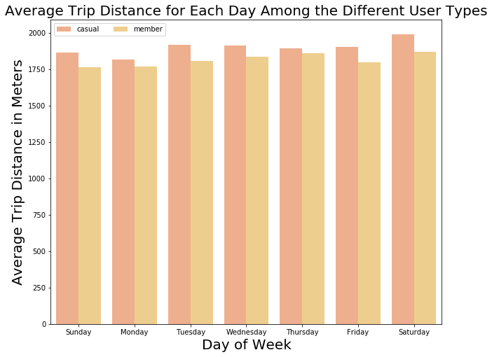

```python
plt.figure(figsize = [10,8])
sb.barplot(data=df_clean, x='start_day', y='distance', hue = 'member_casual', palette = 'autumn', capsize = .1, alpha = .5, ci = None);
plt.xlabel('Day of Week', fontsize = 20);
plt.ylabel('Average Trip Distance in Meters', fontsize = 20);
plt.title('Average Trip Distance for Each Day Among the Different User Types', fontsize = 20)
plt.legend(ncol = 2);
```

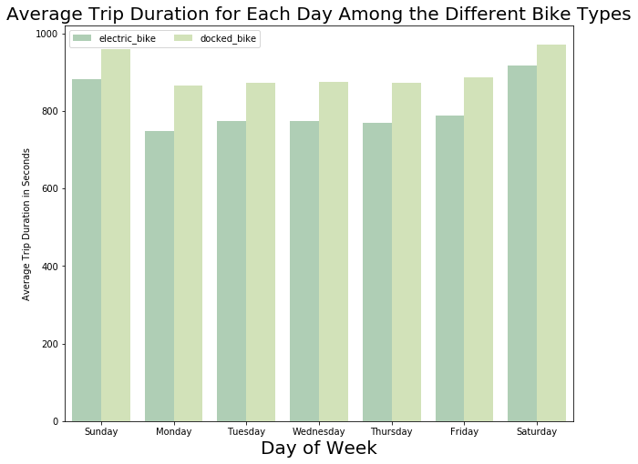

```python
plt.figure(figsize = [10,8])
sb.barplot(data=df_clean, x='start_day', y='duration_sec', hue = 'rideable_type', palette = 'summer', capsize = .1, alpha = .5, ci = None);
plt.xlabel('Day of Week', fontsize = 20);
plt.ylabel('Average Trip Duration in Seconds')
plt.title('Average Trip Duration for Each Day Among the Different Bike Types', fontsize = 20)
plt.legend(ncol = 2);
```

In this visualization, we can see that both casual users and members spent the most time on the docked bikes on Saturdays and Sundays, and they spent the most time on electric bikes on Saturdays.

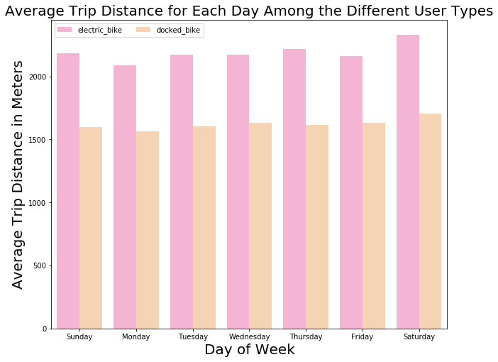

```python
plt.figure(figsize = [10,8])
sb.barplot(data=df_clean, x='start_day', y='distance', hue = 'rideable_type', palette = 'spring', capsize = .1, alpha = .5, ci = None);
plt.xlabel('Day of Week', fontsize = 20);
plt.ylabel('Average Trip Distance in Meters', fontsize = 20);
plt.title('Average Trip Distance for Each Day Among the Different User Types', fontsize = 20)
plt.legend(ncol = 2);
```

In this visualization, we can see that people went further on Saturdays on the electric bikes than on any other day, and we can also see a significant difference in the length traveled between users of electric bikes vs. users of docked bikes.

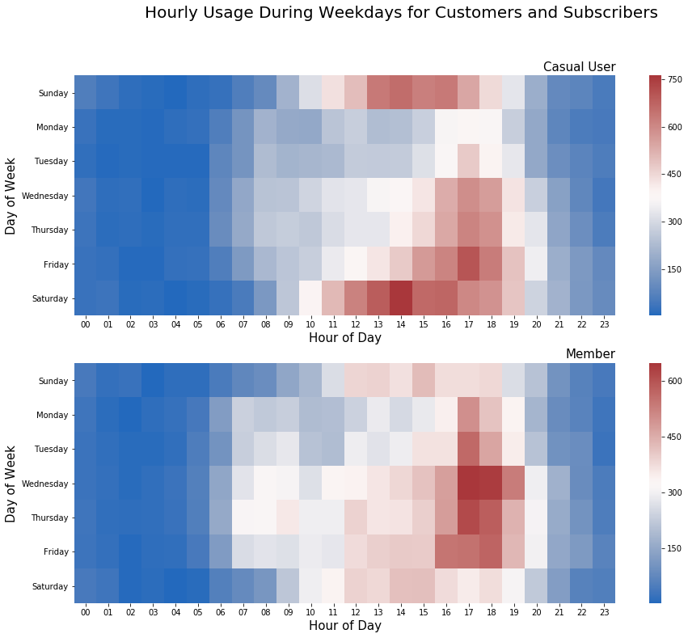

```python
#heatmap to view concentration of of
#https://github.com/kzhang789/Communicate-data-findings/blob/master/fordgobike_exploration.ipynb


plt.figure(figsize = [15,12])

plt.suptitle('Hourly Usage During Weekdays for Customers and Subscribers', fontsize = 20)

plt.subplot(2, 1, 1)
customers = df_clean.query('member_casual == "casual"')
ct_counts = customers.groupby(['start_day', 'start_hour']).size()
ct_counts = ct_counts.reset_index(name='count')
ct_counts = ct_counts.pivot(index='start_day', columns='start_hour', values='count')
sb.heatmap(ct_counts, cmap='vlag');
plt.title('Casual User', loc='right', fontsize = 15);
plt.xlabel('Hour of Day', fontsize = 15);
plt.ylabel('Day of Week', fontsize = 15);

plt.subplot(2, 1, 2)
subscribers = df_clean.query('member_casual == "member"')
st_counts = subscribers.groupby(['start_day', 'start_hour']).size()
st_counts = st_counts.reset_index(name='count')
st_counts = st_counts.pivot(index='start_day', columns='start_hour', values='count')
sb.heatmap(st_counts, cmap='vlag');
plt.title('Member', loc='right', fontsize = 15);
plt.xlabel('Hour of Day', fontsize = 15);
plt.ylabel('Day of Week', fontsize = 15);
```

In this visualization we can see that casual users started their ride around 2 PM on Saturdays the most, and members started their rides around 5-6 PM on Wednesdays the most.

### Talk about some of the relationships you observed in this part of the investigation. Were there features that strengthened each other in terms of looking at your feature(s) of interest?

> I wanted to see the interaction between the hour started, the day started, and the different user types, and the heatmap gives a good visual of these interactions. We can see that members typically used the bikes in the evenings on week nights as opposed to the casual users who started more trips on Saturdays and Sundays and varied their start times from the late morning to the late evening.

### Were there any interesting or surprising interactions between features?

> It was interesting to see that the people who used electric bikes went further than the people who used docked bikes. Even though there are far fewer electric bikes, they seem to attract people who want to go for longer distance bike rides. It also is interesting to me that the distance and duration variables are so weakly correlated.

> At the end of your report, make sure that you export the notebook as an html file from the `File > Download as... > HTML` menu. Make sure you keep track of where the exported file goes, so you can put it in the same folder as this notebook for project submission. Also, make sure you remove all of the quote-formatted guide notes like this one before you finish your report!